# Exploratory Data Analysis in Action - EDA: Number of attacks

In this section we explore the [*Arial Bombing Data Set*](https://www.kaggle.com/usaf/world-war-ii) and apply techniques referred to as **Exploratory Data Analysis**.

## Teilbereich A

**Import statements**

```python
import numpy as np
import pandas as pd
import matplotlib.pyplot as plt
%matplotlib inline
```

**Global settings**

```python
pd.options.display.max_rows = 999
pd.options.display.max_columns = 100
plt.rcParams["figure.figsize"] = [15,6]
```

**Load data set**

```python
import pickle
gdf_europe = pickle.load( open( "../data/gdf_europe.p", "rb" ) )
europe = pickle.load( open( "../data/europe.p", "rb" ) )
```

## Research questions

**@Number of attacks**

- Q1: How many attacks were launched between 1939 and 1945 over Europe?
- Q2: Which Allied Force was responsible for the most of the attacks? Did this change over time?
- Q3: Which Allied Force launched the most attacks against Germany?
- Q4: Is there a seasonal pattern in the attacks against Germany (e.g. winter vs. summer)?
- Q5: Which area experienced the highest number of attacks? Did the area change over time?

```python
df_noa = gdf_europe.copy()
```

> **Q1: How many attacks were launched between 1939 and 1945 over Europe?**

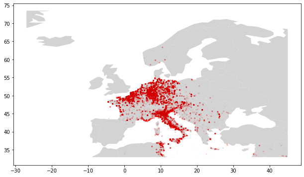

```python
import geopandas as gpd
from shapely.geometry import Polygon
world = gpd.read_file(gpd.datasets.get_path('naturalearth_lowres'))
poly_europe = gpd.GeoSeries([Polygon([(-27,33), (45,33), (45,73.5), (-27,73.5)])])
bb_europe = gpd.GeoDataFrame({'geometry': poly_europe})
# assign crs
bb_europe.crs = {'init':'epsg:4326'}
bb_europe

europe = gpd.overlay(world, bb_europe, how='intersection')
europe.crs = {'init': 'epsg:4326'}

base = europe.plot(facecolor='lightgray')
gdf_europe.plot(ax=base, marker='o', color='red', markersize=5, alpha=0.01);
```

```python
numberOfAttacks = df_noa.shape[0]
print("There were {} attacks between 1939 and 1945".format(numberOfAttacks))
```

```
There were 120068 attacks between 1939 and 1945
```

> **Q2: Which Allied Force was responsible for the most of the attacks? Did this change over time?**

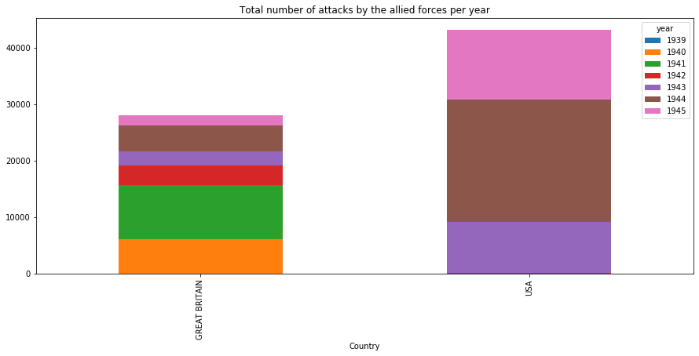

```python
numberOfAttacks = df_noa.groupby(["Country", "year"])["Country"].count() # filter
numberOfAttacks = pd.Series(numberOfAttacks).where(lambda x : x > 10).dropna().unstack("year") # exclude all cells that has less attacks than 10 and convert series to dataframe by using unstack()-function
numberOfAttacks[[1939, 1940, 1941, 1942, 1943, 1944, 1945]].plot(kind="bar", title = "Total number of attacks by the allied forces per year",
                                                                 stacked = True)
```

```python
numberOfAttacks
```

| year Country | 1939 | 1940 | 1941 | 1942 | 1943 | 1944 | 1945 |
| --- | --- | --- | --- | --- | --- | --- | --- |
| GREAT BRITAIN | 41.0 | 6081.0 | 9511.0 | 3524.0 | 2529.0 | 4505.0 | 1808.0 |
| USA | NaN | 28.0 | 18.0 | 125.0 | 9050.0 | 21571.0 | 12303.0 |

Bis 1943 hat Großbritanien die meisten Angriffe durchgeführt, ab 1943 fingen auch die USA richtig an und haben bereits 1944 insgesamt mehr Angriffe durchgeführt als Großbritanien

> **Q3: Which Allied Force launched the most attacks against Germany?**

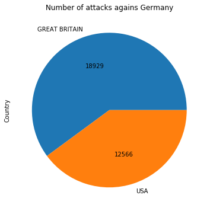

```python
attackOnGermany = df_noa["Target Country"]=="GERMANY"
df_noa_Germany = df_noa[attackOnGermany]
attackOnGermany_number = df_noa_Germany["Country"].value_counts()
sumOfAttacks = attackOnGermany_number.sum()
attackOnGermany_number.plot.pie(title = "Number of attacks agains Germany", autopct=lambda p: '{:.0f}'.format(p * sumOfAttacks / 100))   ###  autopct-> schreibt zahlen in das Kreisdiagramm. '{:.0f}' rundet auf 0 Nachkommastellen
```

[figure not shown]

```python
df_noa["season"] = df_noa["month"]
df_noa.loc[((df_noa["season"] == 12) |
            (df_noa["season"] == 1) |
            (df_noa["season"] == 2)),
            ["season"]] = "winter"
df_noa.loc[((df_noa["season"] == 3) |
            (df_noa["season"] == 4) |
            (df_noa["season"] == 5)),
            ["season"]] = "spring"
df_noa.loc[((df_noa["season"] == 6) |
            (df_noa["season"] == 7) |
            (df_noa["season"] == 8)),
            ["season"]] = "summer"
df_noa.loc[((df_noa["season"] == 9) |
            (df_noa["season"] == 10) |
            (df_noa["season"] == 11)),
            ["season"]] = "autumn"
seasonal_pattern = df_noa["season"].value_counts()
seasonal_pattern = seasonal_pattern.sort_index()
seasonal_pattern.plot.pie(y='', title = "Seasonal Pattern of attacks on Germany",autopct="%1.1f%%")
```

[figure not shown]

```python
seasonal_pattern.plot.bar(y='', title = "Seasonal Pattern of attacks on Germany")
```

> **Q5: Which area in Germany experienced the highest number of attacks? Did the area change over time?**

```
 1940 war es Berlin.
 1941 wurde Koeln am meisten angegriffen, insgesamt bis jetzt aber Hamburg
 1943 insgesamt Bremen
 Danach bis zum Ende des Krieges war es jaehrlich Berlin, auch insgesamt
```

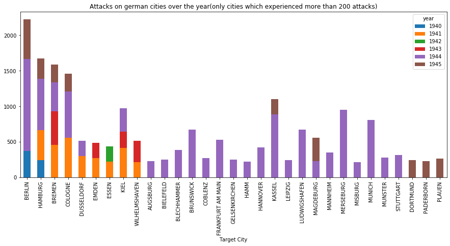

```python
number_of_attacks_city = (df_noa_Germany.groupby(["year", "Target City"])["Target City"].count())
number_of_attacks_city = pd.Series(number_of_attacks_city).where(lambda x : x>200).dropna().unstack("year")
number_of_attacks_city[[1940, 1941, 1942, 1943, 1944, 1945]].plot(kind = "bar", title = "Attacks on german cities over the year" +
                                                                "(only cities which experienced more than 200 attacks)", stacked = True)
print(" 1940 war es Berlin. \n 1941 wurde Koeln am meisten angegriffen, insgesamt bis jetzt aber Hamburg \n 1943 insgesamt Bremen \n" +
     " Danach bis zum Ende des Krieges war es jaehrlich Berlin, auch insgesamt")
```

```python
df_noa.sample(5)
```

|  | Mission ID | Mission Date | Country | Aircraft Series | Target Country | Target City | Target Type | Target Industry | Target Latitude | Target Longitude | Attacking Aircraft | High Explosives Weight (Tons) | Total Weight (Tons) | year | month | day | Altitude (meters) | Altitude(meters) | geometry | season |
| --- | --- | --- | --- | --- | --- | --- | --- | --- | --- | --- | --- | --- | --- | --- | --- | --- | --- | --- | --- | --- |
| 70167 | 70339 | 1940-12-13 | GREAT BRITAIN | WELL | GERMANY | BREMEN | FLAK BATTERY | GUN EMPLACEMENTS | 53.08 | 8.72 | NaN | NaN | NaN | 1940 | 12 | 13 | NaN | NaN | POINT (8.72000 53.08000) | winter |
| 164366 | 164828 | 1945-01-28 | NaN | B17 | GERMANY | COLOGNE | NaN | "RR INSTALLATIONS, TRACKS, MARSHALLING YARDS... | 50.93 | 6.95 | 1.0 | 3.0 | 3.0 | 1945 | 1 | 28 | NaN | NaN | POINT (6.95000 50.93000) | winter |
| 168679 | 169141 | 1943-07-09 | USA | B17 | ITALY | BISCAPI | UNIDENTIFIED TARGET | UNIDENTIFIED TARGETS | 37.03 | 14.47 | NaN | 21.0 | 21.0 | 1943 | 7 | 9 | 6858.0 | NaN | POINT (14.47000 37.03000) | summer |
| 141282 | 141743 | 1944-12-29 | NaN | B24 | ITALY | UDINE | NaN | "RR INSTALLATIONS, TRACKS, MARSHALLING YARDS... | 46.05 | 13.23 | 12.0 | NaN | 28.0 | 1944 | 12 | 29 | NaN | NaN | POINT (13.23000 46.05000) | winter |
| 165300 | 165762 | 1945-01-29 | USA | B24 | GERMANY | MUNSTER | R R | "RR INSTALLATIONS, TRACKS, MARSHALLING YARDS... | 50.13 | 8.46 | 9.0 | 1.0 | 1.0 | 1945 | 1 | 29 | NaN | NaN | POINT (8.46000 50.13000) | winter |

> **Q6: How many attacks per year?**

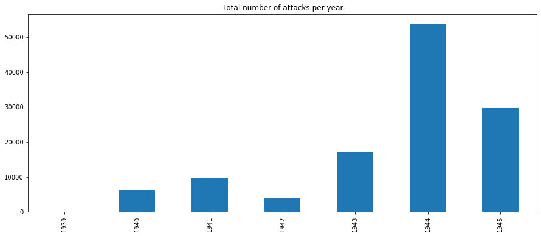

```python
total_number_of_attacks = df_noa["year"].value_counts().sort_index()
total_number_of_attacks.plot(kind = "bar", title = "Total number of attacks per year")
```

> **Q7: Which Target Country experienced the highest number of attacks? Did this change over time?**

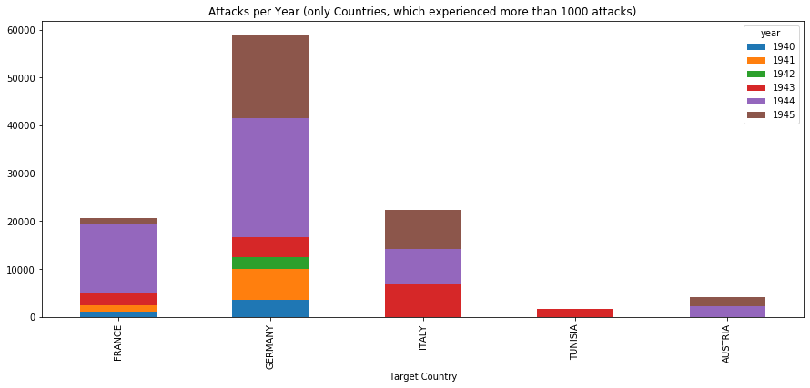

```python
number_of_attacks_country = (df_noa.groupby(["year", "Target Country"])["Target Country"].count())
number_of_attacks_country = pd.Series(number_of_attacks_country).where(lambda x : x > 1000).dropna().unstack("year")
number_of_attacks_country[[1940, 1941, 1942, 1943, 1944, 1945]].plot(kind = "bar",
                                                                     title = "Attacks per Year (only Countries, which experienced more than 1000 attacks)", stacked = True)
```

## Teilbereich B

**Load data set**

```python
import pickle
gdf_europe = pickle.load( open( "../data/gdf_europe.p", "rb" ) )
europe = pickle.load(open( "../data/europe.p", "rb" ) )
germany = pickle.load(open("../data/germany.p", "rb"))
gdf_germany = pickle.load(open("../data/gdf_germany.p", "rb"))
```

## Research questions

**@Airplanes**

- Q1: Which type of airplane types was mostly engaged over?
- Q2: At what height do airplanes operate? At what height to the 10 most common airplane types operate?
- Q3: Which type of airplane carried the heaviest bombs? Which were the 10 most dangerous airplane types with respect to carried explosives?
- Q4: Which Allied Force uses which airplane when and where?

```python
df_airpl = gdf_europe.copy()
```

```python
df_airpl.columns
```

```
Index(['Mission ID', 'Mission Date', 'Country', 'Aircraft Series',
       'Target Country', 'Target City', 'Target Type', 'Target Industry',
       'Target Latitude', 'Target Longitude', 'Attacking Aircraft',
       'High Explosives Weight (Tons)', 'Total Weight (Tons)', 'year', 'month',
       'day', 'Altitude (meters)', 'Altitude(meters)', 'geometry'],
      dtype='object')
```

> **Q1: Which type of airplane is mostly engaged?**

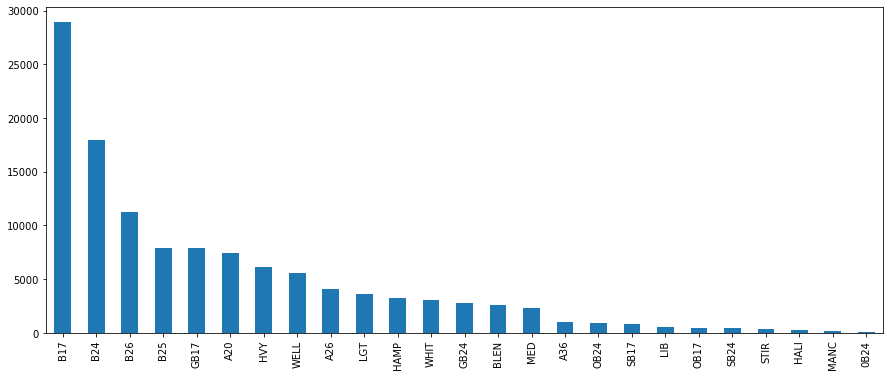

```python
airplanes = df_airpl['Aircraft Series'].value_counts().where(lambda x : x > 50).dropna()
airplanes.plot.bar()
```

> **Q2: At what height do airplanes operate? At what height to the 10 most common airplane types operate?**

```python
df_airpl.head(5)
```

|  | Mission ID | Mission Date | Country | Aircraft Series | Target Country | Target City | Target Type | Target Industry | Target Latitude | Target Longitude | Attacking Aircraft | High Explosives Weight (Tons) | Total Weight (Tons) | year | month | day | Altitude (meters) | Altitude(meters) | geometry |
| --- | --- | --- | --- | --- | --- | --- | --- | --- | --- | --- | --- | --- | --- | --- | --- | --- | --- | --- | --- |
| 0 | 1 | 1943-08-15 | USA | A36 | ITALY | SPADAFORA | NaN | NaN | 38.22 | 15.37 | NaN | 10.0 | 10.0 | 1943 | 8 | 15 | NaN | NaN | POINT (15.37000 38.22000) |
| 2 | 3 | 1943-08-15 | USA | A36 | ITALY | COSENZA | NaN | NaN | 39.27 | 16.25 | NaN | 9.0 | 9.0 | 1943 | 8 | 15 | NaN | NaN | POINT (16.25000 39.27000) |
| 3 | 4 | 1943-08-15 | USA | A36 | ITALY | GIOJA TAURO | NaN | NaN | 38.43 | 15.90 | NaN | 7.5 | 7.5 | 1943 | 8 | 15 | NaN | NaN | POINT (15.90000 38.43000) |
| 8 | 9 | 1943-08-15 | USA | A36 | ITALY | SCILLA | NaN | NaN | 38.23 | 15.72 | NaN | 0.0 | 0.0 | 1943 | 8 | 15 | NaN | NaN | POINT (15.72000 38.23000) |
| 9 | 10 | 1943-08-15 | USA | A36 | ITALY | GIOJA TAURO | NaN | ARMAMENT AND ORDNANCE PLANTS | 38.43 | 15.90 | NaN | 0.0 | 0.0 | 1943 | 8 | 15 | NaN | NaN | POINT (15.90000 38.43000) |

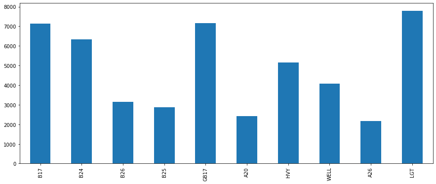

```python
airplane_usage = df_airpl["Aircraft Series"].value_counts()
df_airpl["Altitude (meters)"].mean()
ten_most_used = airplane_usage.nlargest(10)
ten_most_used = ten_most_used.index
v = []
for airplane_type in ten_most_used:
    airplane_type_numbers = df_airpl.loc[df_airpl["Aircraft Series"] == airplane_type] ### Die zwei == zeigen an, dass wir vergleichen und am Ende ein boolscher Operator rauskommt mit true false als Ergebnis
    v.append(airplane_type_numbers["Altitude (meters)"].mean())
v = pd.Series(v)
v.index = ten_most_used
v
v.plot.bar()
```

> **Q3: Which type of airplane carried the heaviest bombs? Which were the 10 most dangerous airplane types with respect to carried explosives?**

```python
df_airpl.groupby("Aircraft Series")["High Explosives Weight (Tons)"].sum().sort_values(ascending = False)[0:10]
```

```
Aircraft Series
B17     789151.500
HVY     739009.000
B24     549470.900
B26     317893.000
GB17    187584.000
B25     143020.135
GB24     69932.000
A20      46179.000
LGT      32839.000
OB24     32530.000
Name: High Explosives Weight (Tons), dtype: float64
```

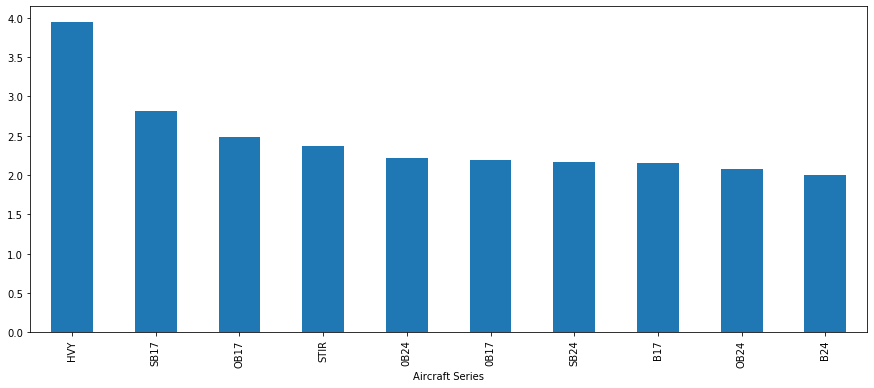

```python
df_airpl_bomb = df_airpl["Attacking Aircraft"].notnull() ### wir filtern Nan heraus und boole kommt heraus
df_airpl_bomb = df_airpl[df_airpl_bomb] ### hier machen wir aus dem booleean einen Datensatz ohne Nan mit dem wor weiterarbeiten können
carried = df_airpl_bomb.groupby("Aircraft Series")["High Explosives Weight (Tons)"].sum().sort_values(ascending = False) ## Wie viel wurde pro flugzeugtyp abgeworfen
noa = df_airpl_bomb.groupby("Aircraft Series")["Attacking Aircraft"].sum().sort_values(ascending = False)
noa =noa[noa!=0] ### Filtern raus, was null ist
ten_most_dangerous = (carried / noa).nlargest(10) ### Wie viel wurde pro Flugzeug, nicht pro geflogenem Angriff abgeworfen?
ten_most_dangerous.plot.bar()
```

> **Q4: Which Allied Force uses which airplane when and where?**  
> *This question is for sure a huge one. We suggest to write a function (or script) that plots for each year the Allied attacks over Europe for any specified airplane type.*

```python
df_airpl['Aircraft Series'].unique()
```

```
array(['A36', 'LGT', 'B17', 'GB17', 'HVY', 'B26', 'B25', 'A20', 'GB24',
       'B24', 'OB24', 'SB24', 'A26', 'LIB', 'OB17', 'HALI', 'SB17',
       'HAMP', '0B24', 'BLEN', 'WELL', 'MED', '0B17', 'WHIT', 'STIR',
       'ALBA', 'BATT', 'MANC', 'SWORD', 'AUDA', 'VALE', 'MARY', 'BEAU',
       'HURR', 'TOM', nan, 'BEAUF'], dtype=object)
```

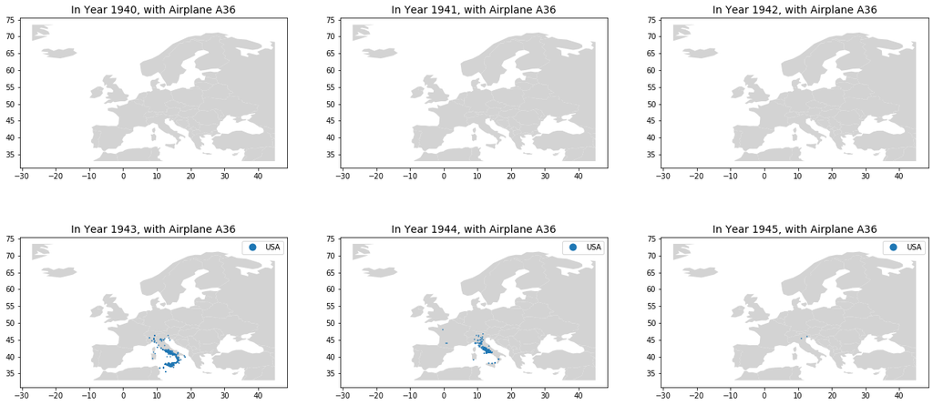

```python
import geopandas as gpd
from shapely.geometry import Polygon
world = gpd.read_file(gpd.datasets.get_path('naturalearth_lowres'))
poly_europe = gpd.GeoSeries([Polygon([(-27,33), (45,33), (45,73.5), (-27,73.5)])])
bb_europe = gpd.GeoDataFrame({'geometry': poly_europe})
bb_europe.crs = {'init':'epsg:4326'}
bb_europe

europe = gpd.overlay(world, bb_europe, how='intersection')
europe.crs = {'init': 'epsg:4326'}

year = [1940, 1941, 1942, 1943, 1944, 1945]


def where_and_when (airplane):
    fig = plt.figure(figsize=(22,10))      ### erstellt schonmal die vorlage für den plot

    for i, y in enumerate(year):      ### enumerate um 2 werte zu haben (gibt den jahren indizes)
        all_years_airplanes = df_airpl.loc[(df_airpl["year"]==y) & (df_airpl["Aircraft Series"]==airplane)].copy() ## Arbeitskopie des Originaldatensatzes anlegen      ### copy() sonst warnungen
        all_years_airplanes.Country.replace(np.nan, "not known", inplace=True)       ### ersetze nan-werte durch `not known`sonst bias
        ax = fig.add_subplot(2,3,i+1)      ### (rows, columns, index (starting at 1) )
        base = europe.plot(ax=ax, facecolor="lightgray")       ### Setze die Europakarte als Basis für die Kartenerstellung
        all_years_airplanes.plot(ax=ax, categorical=True, column="Country", markersize=0.5, legend = True) ### plottet alle jahre
        ax.set_title(f"In Year {y}, with Airplane {airplane}", size=14)      ### titel für die einelnen plots
    return
where_and_when("A36")

#all_airplanes = df_airpl["Aircraft Series"].unique()
#for airplane in all_airplanes:
#   where_and_when(airplane)
```

[figure not shown]

The Airplane Type A-36

## Teilbereich C

**Load data set**

```python
import pickle
gdf_europe = pickle.load( open( "../data/gdf_europe.p", "rb" ) )
europe = pickle.load( open( "../data/europe.p", "rb" ) )
```

## Research questions

**@Targets**

- Q1: Which cities were the 15 most frequent targets?
- Q2: How much high explosives (in tons) went down on the 25 most frequent targets?
- Q3: How did the aerial attacks change over time for the 15 most frequent targeted cities?

```python
df_tar = gdf_europe.copy()
```

```python
df_tar.columns
```

```
Index(['Mission ID', 'Mission Date', 'Country', 'Aircraft Series',
       'Target Country', 'Target City', 'Target Type', 'Target Industry',
       'Target Latitude', 'Target Longitude', 'Attacking Aircraft',
       'High Explosives Weight (Tons)', 'Total Weight (Tons)', 'year', 'month',
       'day', 'Altitude (meters)', 'Altitude(meters)', 'geometry'],
      dtype='object')
```

> **Q1: Which cities were the 15 most frequent targets?**

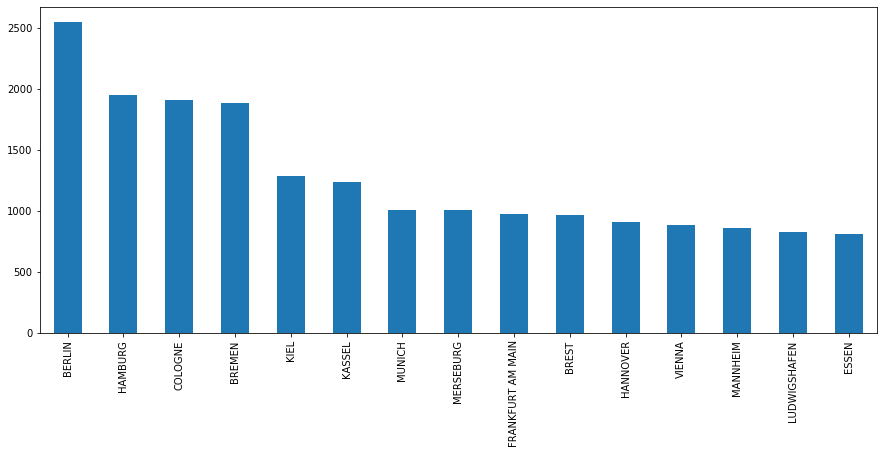

```python
target_cities = df_tar["Target City"].value_counts().nlargest(15)
target_cities.plot.bar()
```

Underneath you can see a picture of Berlin 1945, shot at the Brandenburg Gate we all know: The area extending north beyond the Brandenburg Gate was later controlled by Soviets for almost 40 year. Note the portrait of Stalin in the center.

[figure not shown]

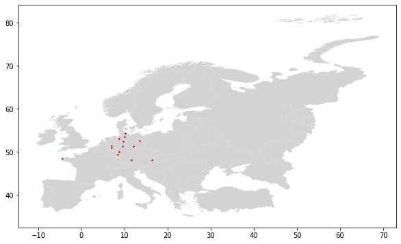

```python
import geopandas
filepath = "../data/Europe_borders.shp"

top_15_subset = df_tar.loc[df_tar["Target City"].isin(target_cities.index),:]

europe = geopandas.read_file(filepath)
base = europe.plot(facecolor='lightgray');
top_15_subset.plot(ax = base, marker='.', color='red', markersize=2.5, alpha=0.01)
```

> **Q2: How much high explosives (in tons) went down on the 25 most frequent targets?**

```python
top_25 = df_tar.groupby("Target City")["Target City"].count().sort_values(ascending = False)[0:25].index
top_25
```

```
Index(['BERLIN', 'HAMBURG', 'COLOGNE', 'BREMEN', 'KIEL', 'KASSEL', 'MUNICH',
       'MERSEBURG', 'FRANKFURT AM MAIN', 'BREST', 'HANNOVER', 'VIENNA',
       'MANNHEIM', 'LUDWIGSHAFEN', 'ESSEN', 'WILHELMSHAVEN', 'DUSSELDORF',
       'BRUNSWICK', '45 00 N 010 40 E', 'GELSENKIRCHEN', 'EMDEN', 'DUISBURG',
       'MAGDEBURG', 'MUNSTER', 'DORTMUND'],
      dtype='object', name='Target City')
```

```python
df_tar_subset = df_tar.loc[df_tar["Target City"].isin(top_25),:]
result = df_tar_subset.groupby("Target City")["High Explosives Weight (Tons)"].sum().sort_values(ascending = False)
```

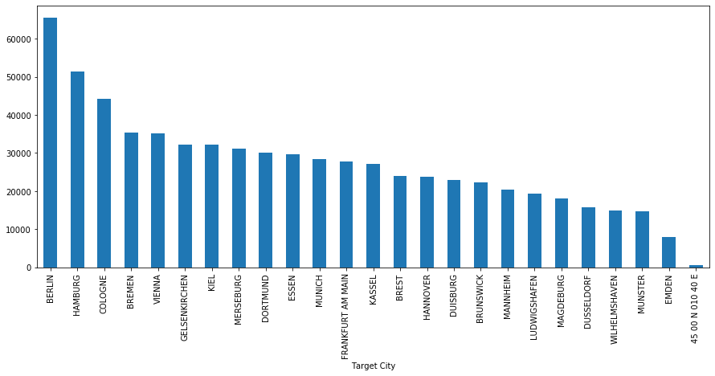

```python
result.plot.bar()
```

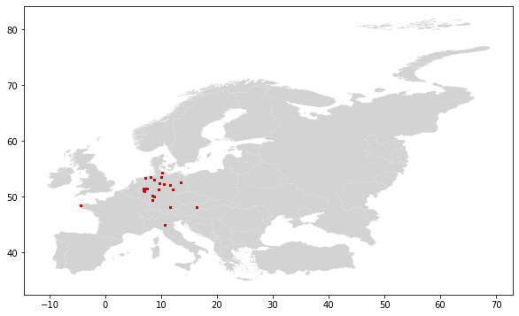

```python
import geopandas
filepath = "../data/Europe_borders.shp"

europe = geopandas.read_file(filepath)
base = europe.plot(facecolor='lightgray');
df_tar_subset.plot(ax = base, marker='.', color='red', markersize=10, alpha=0.01)
```

> **Q3: How did the aerial attacks change over time for the 15 most frequent targeted cities?**

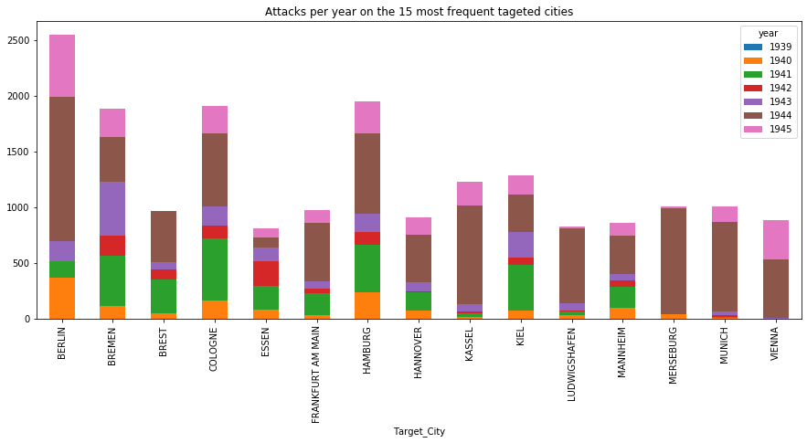

```python
cities_fifteen = target_cities.index
df_tar_renamed = df_tar.rename(columns = {"Target City" : "Target_City"})
df_tar_new = df_tar_renamed.Target_City.isin(cities_fifteen)
df_tar_new = df_tar_renamed[df_tar_new]
number_of_attacks = (df_tar_new.groupby(["year", "Target_City"])["Target_City"].count())
number_of_attacks = pd.Series(number_of_attacks).dropna().unstack("year")
number_of_attacks[[1939, 1940, 1941, 1942, 1943, 1944, 1945]].plot(kind = "bar",
                                                                   title = "Attacks per year on the 15 most frequent tageted cities",
                                                                    stacked = True)
```

> **Q4: How much high explosives (tons) went down in one attack in the 15 most frequent targeted cities in average?**

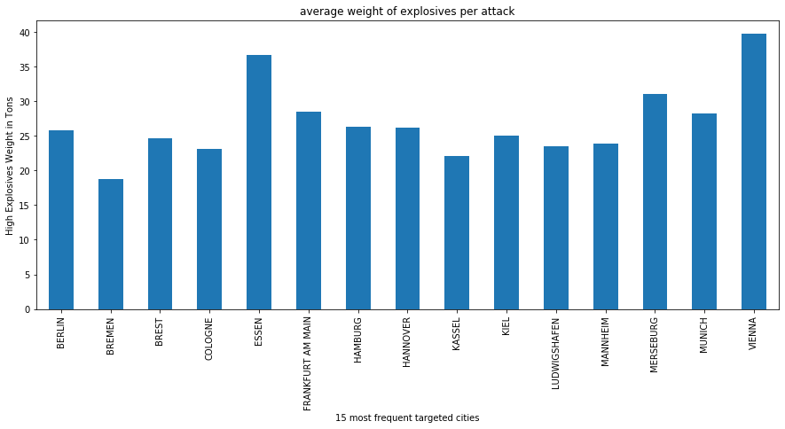

```python
number_of_attacks = df_tar_new["Target_City"].value_counts()
number_of_explosives = df_tar_new.groupby("Target_City")["High Explosives Weight (Tons)"].sum()
average = number_of_explosives / number_of_attacks
plt.ylabel("High Explosives Weight in Tons")
plt.xlabel("15 most frequent targeted cities")
average.plot.bar(title = "average weight of explosives per attack")
```

A Lancaster drops a bomb (left), incendiary bombs and bundles of incendiary bombs (right) on Duisburg on 15 October 1944.

[figure not shown]

Source(https://en.wikipedia.org/wiki/Operation_Hurricane_(1944)

[figure not shown]

Image of Duisburg after the attacks in Operation Hurricane (Oct 14-15 1944) The operation was a 24-hour terror bombing operation to "demonstrate to the enemy in Germany generally the overwhelming superiority of the Allied Air Forces in this theatre". This Image shows Duisburg burning and bombs falling.

[figure not shown]

Source(https://www.lokalkompass.de/duisburg/c-vereine-ehrenamt/operation-hurricane-die-duisburger-schreckenstage-vom-14-15-oktober-1944-ein-rueckblick_a19810#gallery=null)

> **SQ1: How much high explosives (tons) went down in one attack in Berlin on average?**

```python
Attacks_on_Berlin = df_tar['Target City'].value_counts().nlargest(1)
Attacks_on_Berlin
```

```
BERLIN    2546
Name: Target City, dtype: int64
```

```python
Total_Explosives_on_Berlin = df_tar.groupby("Target City")["High Explosives Weight (Tons)"].sum().sort_values(ascending = False)[0]
Total_Explosives_on_Berlin
```

```
65504.0
```

```python
Answer = Total_Explosives_on_Berlin / Attacks_on_Berlin
Answer
```

```
BERLIN    25.728201
Name: Target City, dtype: float64
```

```python
most_attacked_cities_fifteen = df_tar["Target City"].value_counts().nlargest(15)
noa = most_attacked_cities_fifteen.sum()
df_tar_subset = df_tar.loc[df_tar["Target City"].isin(most_attacked_cities_fifteen.index),:]
total_weight = df_tar_subset["Total Weight (Tons)"].sum()
print(f"Mean of high explosives in tons per attack for the 15 most freuquent targeted cities is: {total_weight / noa}.")
```

[output not shown]